# Amostrador de Gibbs

Aishameriane Schmidt

Última atualização: 11 abril 2018

$$\begin{align*}
\newcommand{\norm}[1]{\left\lVert#1\right\rVert}\\
\def\I{{\mathbb I}}\\
\def\P{{\mathbb P}}\\
\def\E{{\mathbb E}}\\
\def\V{{\mathbb V}}\\
\def\R{{\mathbb R}}\\
\def\N{{\mathbb N}}\\
\def\Q{{\mathbb Q}}\\
\newcommand{\Or}{{\mathrm O}}\\
\newcommand{\A}{{\mathcal A}}\\
\newcommand{\C}{{\mathbb C}}\\
\newcommand{\K}{{\mathbb K}}\\
\newcommand{\Z}{{\mathbb Z}}
\end{align*}$$

# Carregando os pacotes

```r
chooseCRANmirror(graphics = FALSE, ind = 10)
if (!require("pacman")) install.packages("pacman")
pacman::p_load(ggplot2, gridExtra, latex2exp, RColorBrewer, ggfortify, car, rgl, rglwidget, psych, rmutil, VGAM)
```

# Introdução

A origem do amostrador de Gibbs é o trabalho de Geman e Geman (1984), cuja aplicação era em [campos aleatórios de Gibbs](http://www.nlpr.ia.ac.cn/users/szli/MRF_Book/Chapter_1/node12.html) (*Gibbs random fields*). Pode-se mostrar que o amostrador de Gibbs é um caso particular do algoritmo de Metropolis-Hastings, onde os parâmetros são agrupados em blocos que, por sua vez, são amostrados de forma condicional uns aos outros. Por exemplo, supondo que temos interesse no parâmetro $\theta$ e que ele pode ser escrito como uma partição $\theta = (\theta_1, \theta_2, \ldots, \theta_p)$ (onde $\theta_i, \ i \in \{1, \ldots, p\}$ pode ser escalar ou vetorial), então usaremos as distribuições condicionais de $\theta_i| \theta_1, \ldots, \theta_{i-1}, \theta_{i+1}, \ldots, \theta_p$, $\forall\ i$ de maneira a obter amostras de todos os $\theta_i$ (Chib 2001). Esse procedimento equivale a escolher como densidade candidata as densidades condicionais a todos os outros parâmetros (também chamada de *full conditional*). Como resultado, a probabilidade de aceitação, a cada passo, é sempre igual a $1$ (Chib 2013). No entanto, como não estou falando de Metropolis-Hastings antes, vou fazer a abordagem partindo diretamente do Gibbs.

Assim como os demais métodos de MCMC, o amostrador de Gibbs é uma técnica de gerar variáveis aleatórias de uma distribuição $f$ de maneira indireta, sem necessariamente amostrar de $f$. (Robert and Casella 2010) cita duas principais vantagens do amostrador de Gibbs: a primeira é que o método usa praticamente apenas a densidade alvo e a segunda é que nos permite quebrar um problema complexo em diversos problemas de dimensão menor. No exemplo do parágrafo anterior, se temos $m$ parâmetros, poderíamos “dividir” o problema em amostrar condicionalmente cada um dos $m$ parâmetros, formando uma cadeia de Markov cuja densidade estacionária fosse a posteriori de $\theta$. (Casella and George 1992) chamam atenção para o fato de que, embora seja amplamente aplicado em problemas bayesianos, é possível utilizar o amostrador de Gibbs em problemas frequentistas também.

# Noções básicas

**Definição 1** Amostrador de Gibbs (adaptado de (Robert and Casella 1999))

Suponha que para algum $p>1$ a variável aleatória $\theta \in \Theta$ pode ser escrita como $\theta = (\theta_1, \theta_2, \ldots, \theta_p)$ (onde $\theta_i, \ i \in \{1, \ldots, p\}$ pode ser escalar ou vetorial). Suponha ainda que pode-se simular das densidades univariadas condicionais $f_1, \ldots, f_p$, isto é, é possível amostrar
$$\theta_i|\underline{\theta}_1, \ldots, \underline{\theta}_{i-1}, \underline{\theta}_{i+1}, \ldots, \underline{\theta}_p \sim f_i(\underline{\theta}_{i}|\underline{\theta}_1, \ldots, \underline{\theta}_{i-1}, \underline{\theta}_{i+1}, \ldots, \underline{\theta}_p)$$
com $i=1, \ldots, p$. O *algoritmo de amostragem de Gibbs* (ou *amostrador de Gibbs*) correspondente é dado pela transição de $\theta^{(t)}$ para $\theta^{(t+1)}$:

**Algoritmo 1 - Amostrador de Gibbs**

- Dado $\theta^{(t)} = (\theta_1^{(t)}, \ldots, \theta_p^{(t)})$, gere
  1. $\theta_1^{(t+1)} \sim f_1(\theta_1|\theta_2^{(t)}, \ldots, \theta_p^{(t)})$
  2. $\theta_2^{(t+1)} \sim f_2(\theta_2|\theta_1^{(t+1)}, \theta_3^{(t)}, \ldots, \theta_p^{(t)})$

  $\hspace{1cm} \vdots$
  16. $\theta_p^{(t+1)} \sim f_p(\theta_p|\theta_1^{(t+1)}, \theta_2^{(t+1)}, \ldots, \theta_{p-1}^{(t+1)})$

Chamamos as densidades $f_1, \ldots, f_p$ de *full conditionals*. Note que o algoritmo 1 implica que apenas essas densidades são usadas para simulação e, como dito anteriormente, podemos reduzir um problema de dimensão $p$ em $p$ problemas univariados (Robert and Casella 1999).

## Caso bivariado

(Retirado de (Robert and Casella 2010)) Considere $\theta=(\theta_1, \theta_2)$ com distribuição conjunta $f(\theta_1, \theta_2)$ e condicionais denotadas por $f_{\theta_1|\theta_2}$ e $f_{\theta_2|\theta_1}$. Neste caso, o amostrador de Gibbs correspondente é também chamado de *amostrador de Gibss em dois estágios* (*two stage Gibbs sampler*) e consiste em gerar uma cadeia de Markov $\{\theta_1, \theta_2\}$ da seguinte forma:

**Algoritmo 2 - Amostrador de Gibbs em dois estágios**

- Dado $\theta_1^{(0)} = \underline{\theta}_1^{(0)}$, gere
  1. $\theta_2^{(t)} \sim f_{\theta_2|\theta_1}(\cdot | \theta_1^{(t-1)})$
  2. $\theta_1^{(t)} \sim f_{\theta_1|\theta_2}(\cdot | \theta_2^{(t)})$

### Exemplo 2: Modelo hierárquico simples (adaptado de (Robert and Casella 2010) e (Casella and George 1992))

Considere a distribuição dada por
$$f(x, \theta) = {n\choose x} \frac{\Gamma(a+b)}{\Gamma(a)\Gamma(b)}\theta^{x+a+1}(1-\theta)^{n-x+b-1}, \qquad \text{com} \quad 0 \leq \theta \leq 1 \quad \text{e} \quad x = 1, 2, \ldots, n.$$

Nosso interesse é amostrar da marginal de $X$, mas vamos supor que não temos como fazer isso diretamente.

Vamos calcular a densidade marginal de $\theta$:

$$\begin{align*}
f(\theta) &= \sum_{i=1}^n f(x_i, \theta) = \sum_{i=1}^n {n\choose x_i} \frac{\Gamma(a+b)}{\Gamma(a)\Gamma(b)}\theta^{x_i+a+1}(1-\theta)^{n-x_i+b-1}\\
&= \frac{\Gamma(a+b)}{\Gamma(a)\Gamma(b)} \theta^{a-1}(1-\theta)^{b-1} \sum_{i=1}^n {n\choose x_i}\theta^{x_i}(1-\theta)^{n-x_i}\\
&= \frac{\Gamma(a+b)}{\Gamma(a)\Gamma(b)} \theta^{a-1}(1-\theta)^{b-1} \Rightarrow \theta \sim \mathcal{B}(\alpha,\beta)
\end{align*}$$

Note que para sumir com o somatório consideramos que era a f.m.p. de uma v.a. Binomial.

Agora, para calcular a condicional de $x|\theta$, usamos o teorema de Bayes:

$$\begin{align*}
f(x|\theta) &=\frac{f(x,\theta)}{f(\theta)} = \frac{{n\choose x} \frac{\Gamma(a+b)}{\Gamma(a)\Gamma(b)}\theta^{x+a+1}(1-\theta)^{n-x+b-1}}{\frac{\Gamma(a+b)}{\Gamma(a)\Gamma(b)} \theta^{a-1}(1-\theta)^{b-1}}\\
&= {n\choose x} \theta^{x}(1-\theta)^{n-x}
\end{align*}$$

Que é a densidade de uma v.a. Binomial com parâmetros $n$ e $\theta$. Assim, $X|\theta \sim \text{Binomial}(n,\theta)$ e $\theta \sim \mathcal{B}(a,b) \Rightarrow \theta|x \sim \mathcal{B}(x + a, n-x+b)$ e podemos implementar um amostrador de Gibbs da seguinte forma (adaptei o código do (Robert and Casella 2010)).

**Obs:** A densidade marginal de X é uma Beta-Binomial(n,a,b), mas estamos fingindo que não sabemos disso.

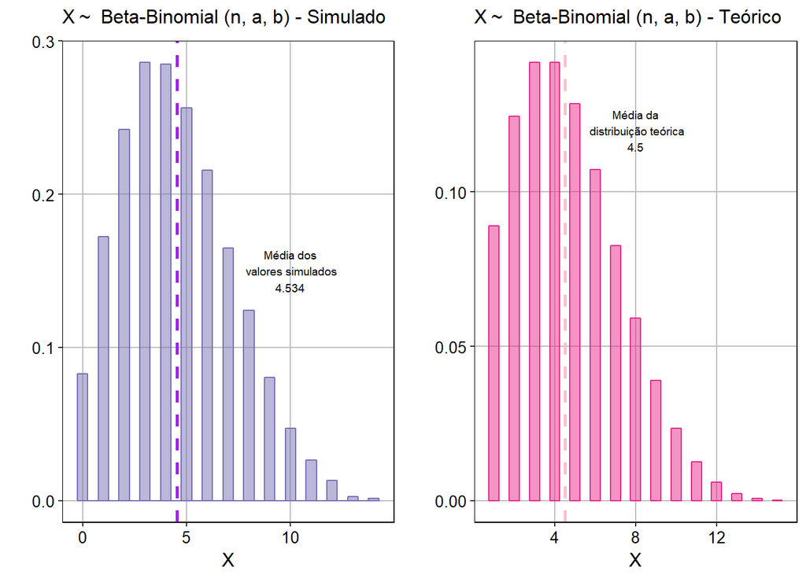

```r
Nsim  <- 5000
n     <- 15
a     <- 3
b     <- 7
x     <-vector()
theta <- vector()

# Valores iniciais
theta[1] <- rbeta(1,a,b)
x[1]     <- rbinom(1,n,theta[1])

for (i in 2:Nsim){
  x[i] <- rbinom(1, n, theta[i-1])
  theta[i] <- rbeta(1, a+x[i], n-x[i]+b)
}

cores <- brewer.pal(6, "Dark2")
cores2 <- brewer.pal(10, "Paired")
cadeiadf <- data.frame(1:Nsim, x, theta)

p1 <- ggplot(cadeiadf, aes(x=cadeiadf$x)) +
    geom_histogram(aes(y=..density..),      # Histogram with density instead of count on y-axis
      binwidth=.5, fill = cores[3], colour = cores[3], alpha=0.5)+
    # stat_function(
    #   fun = function(x, size, shape1, shape2, n, bw){
    #     dbetabinom.ab(x =x, size = n, shape1 = a, shape2 = b)
    # },
    # args = c(size = n, shape1 = a, shape2 = b, n = length(cadeiadf$x), bw = .5), colour = cores2[10], size = 1, geom = "line")+ #dont know what's wrong
  #geom_density(colour = cores2[10])+
  labs(title= TeX('$X \\sim$ Beta-Binomial ($n$,$a$, $b$) - Simulado'), y = "", x= TeX('$X$'), color = "Variável") +
    theme(plot.title=element_text(size = 12),
              text=element_text(size = 12),
              axis.text.x=element_text(colour="black", size = 10),
              axis.text.y=element_text(colour="black", size = 10),
              panel.background = element_blank(),
              panel.grid.major = element_line(colour = "gray"),
              panel.grid.minor = element_line(),
              panel.border = element_rect(colour = "black", fill = NA))
p1 <- p1 + geom_vline(aes(xintercept=mean(cadeiadf$x)),
            color="purple", linetype="dashed", size=1) + annotate("text", x = 10, y = 0.15, label = paste0("Média dos\n valores simulados\n", round(mean(cadeiadf$x),4)), size = 2.5)

p2<- ggplot(cadeiadf, aes(x=theta)) +
    geom_histogram(aes(y=..density..),      # Histogram with density instead of count on y-axis
      binwidth=.05, fill = cores[1], colour = cores[1], alpha=0.5)+
    # stat_function(
    #   fun = function(x, shape1, shape2, n, bw){
    #     dbeta(x = theta, shape1 = a, shape2 = b)
    # },
    # args = c(shape1 = a, shape2 = b, n = length(theta), bw = .5), colour = cores2[10], size = 1)+ #dont know what's wrong
  #geom_density(colour = cores2[4])+
  labs(title= TeX('$\\theta \\sim B(a,b)$'), y = "", x= TeX('$\\theta$'), color = "Variável") +
    theme(plot.title=element_text(size = 12),
              text=element_text(size = 12),
              axis.text.x=element_text(colour="black", size = 10),
              axis.text.y=element_text(colour="black", size = 10),
              panel.background = element_blank(),
              panel.grid.major = element_line(colour = "gray"),
              panel.grid.minor = element_line(),
              panel.border = element_rect(colour = "black", fill = NA))
p2 <- p2 + geom_vline(aes(xintercept=mean(theta)),
            color="darkgreen", linetype="dashed", size=1) + annotate("text", x = 0.65, y = 1.5, label = paste0("Média dos\n valores simulados\n", round(mean(cadeiadf$theta),4)), size = 2.5)

df2 <- data.frame(seq(1,n), dbetabinom.ab(seq(1,n),n,a,b))
names(df2) <- c("X", "densidade")

p3 <- ggplot(df2, aes(x=X, y=densidade)) +
    geom_bar(stat="identity",
      width=.5, fill = cores[4], colour = cores[4], alpha=0.5)+
  labs(title= TeX('$X \\sim$ Beta-Binomial ($n$,$a$, $b$) - Teórico'), y = "", x= TeX('$X$'), color = "Variável") +
    theme(plot.title=element_text(size = 12),
              text=element_text(size = 12),
              axis.text.x=element_text(colour="black", size = 10),
              axis.text.y=element_text(colour="black", size = 10),
              panel.background = element_blank(),
              panel.grid.major = element_line(colour = "gray"),
              panel.grid.minor = element_line(),
              panel.border = element_rect(colour = "black", fill = NA))
p3 <- p3 + geom_vline(aes(xintercept=n*a/(a+b)),
            color="pink", linetype="dashed", size=1) + annotate("text", x = 8, y = 0.12, label = paste0("Média da\n distribuição teórica\n", round(n*a/(a+b),4)), size = 2.5)

grid.arrange(p1, p3, ncol = 2, nrow = 1)
```

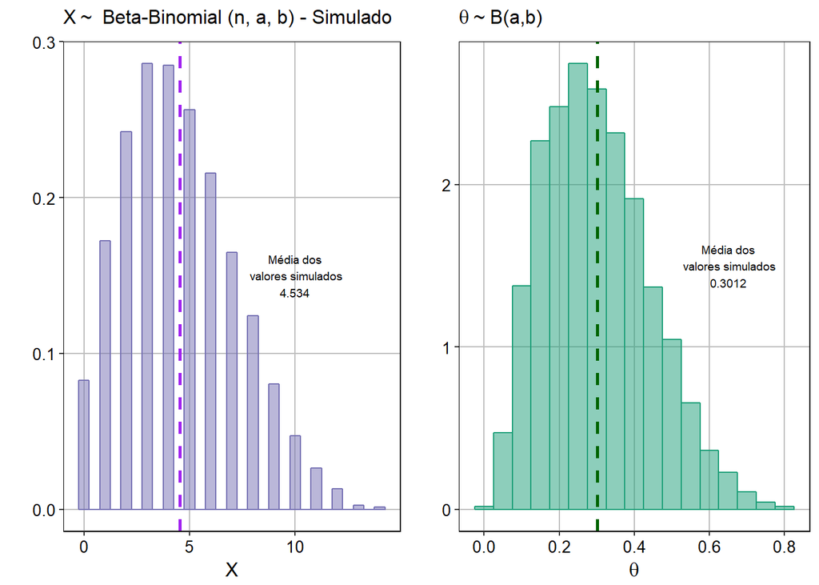

```r
#Plot as distribuições dos x e dos thetas
grid.arrange(p1, p2, ncol = 2, nrow = 1)
```

Obs: A altura dos histogramas dos valores simulados e teóricos está diferente pois para os valores simulados foi utilizada uma função que estima a densidade a partir do histograma. Se você plotar um histograma usando o plot simples do R, vai ver que eles dão iguais.

Obs2: Usei uma função pronta para calcular a beta-binomial (função `dbetabinom.ab` do pacote `VGAM`), mas caso você não consiga usar ele, pode implementar diretamente a densidade a partir da equação:

$$f(X|n, a, b) = \frac{\Gamma(n+1)}{\Gamma(x+1)\Gamma(n-x+1)}\cdot\frac{\Gamma(x+a)\Gamma(n-x+b)}{\Gamma(n+a+b)}\cdot\frac{\Gamma(a+b)}{\Gamma(a)\Gamma(b)}$$

# Referências

Casella, George, and Edward I George. 1992. “Explaining the Gibbs Sampler.” *The American Statistician* 46 (3). Taylor & Francis: 167–74.

Chib, Siddhartha. 2001. “Markov Chain Monte Carlo Methods: Computation and Inference.” In *Handbook of Econometrics*, 5:3569–3649. Elsevier.

———. 2013. “Introduction to Simulation and MCMC Methods.” In *The Oxford Handbook of Bayesian Econometrics*, edited by John Geweke, Gary Koop, and Herman Van Dijk, 183–217. Oxford: Oxford University Press.

Robert, Christian, and George Casella. 1999. *Monte Carlo Statistical Methods*. Springer.

———. 2010. *Introducing Monte Carlo Methods with R*. Vol. 18. Springer.